# Explore Phyloseq

Noah Siegel

19 May, 2021, 11:28

# Reading in the experiment data and exploring the Phyloseq object

The phyloseq package has become a convenient way a managing micobial community data, filtering and visualizing data, performing analysis such as ordination. Along with the standard R environment and packages vegan and vegetarian you can perform virtually any analysis. Today we will

1. Load phyloseq object
2. Perform some QA/QC
3. Filter Data
4. Graphical Summaries
5. Ordination
6. Differential Abundances

## Load our libraries

```r
# Set up global options for nice reports and keeping figures:
knitr::opts_chunk$set(fig.width=14, fig.height=8, fig.align="center",
                      warning=FALSE, message=FALSE)
```

Lets start by loading libraries

```r
source("../R/dependencies.R")
renv::restore()
```

```
## * The library is already synchronized with the lockfile.
```

```r
nice_colors = c("#999999", "#E69F00", "#56B4E9","#e98756","#c08160","#5800e6", "#CDDC49", "#C475D3",
                "#E94B30", "#233F57", "#FEE659", "#A1CFDD", "#F4755E", "#D6F6F7","#EB6D58", "#6898BF")
```

## Read in the dataset,

Lets first read in the Phyloseq object, this is the full dataset 197 generated from the same pipeline used in the data reduction section.

```r
load(file="phyloseq_nochim_silva2.RData")
ls()
```

```
## [1] "encoding"        "inputFile"       "nice_colors"     "ps.silva.nochim"
```

```r
# set the data set used for analysis
ps = ps.silva.nochim

head(otu_table(ps))[,1:10]
```

```
## OTU Table:          [10 taxa and 6 samples]
##                      taxa are columns
##            ASV1 ASV2 ASV3 ASV4 ASV5 ASV6 ASV7 ASV8 ASV9 ASV10
## Bs1_10C_A0 2041   46  944  234  506  119  381   84  150  1140
## Bs1_10C_A5  965   45  961  163  609  304  165  110  256   576
## Bs1_10C_B0 1151   10  731  184  387   73  192   58   90   429
## Bs1_10C_B5  525   21  586  155  361  143  129   39  149   550
## Bs1_10C_C0 1218   10  560  165  320   85  327   52  115   472
## Bs1_10C_C5  352   15  294   61  213  108   68   39   95   242
```

```r
head(sample_data(ps))
```

```
##              SampleID Group Temp Replicate
## Bs1_10C_A0 Bs1_10C_A0   Bs1  10C        A0
## Bs1_10C_A5 Bs1_10C_A5   Bs1  10C        A5
## Bs1_10C_B0 Bs1_10C_B0   Bs1  10C        B0
## Bs1_10C_B5 Bs1_10C_B5   Bs1  10C        B5
## Bs1_10C_C0 Bs1_10C_C0   Bs1  10C        C0
## Bs1_10C_C5 Bs1_10C_C5   Bs1  10C        C5
```

```r
head(tax_table(ps))
```

```
## Taxonomy Table:     [6 taxa by 7 taxonomic ranks]:
##      Kingdom    Phylum             Class               Order
## ASV1 "Bacteria" "Desulfobacterota" "Syntrophobacteria" "Syntrophobacterales"
## ASV2 "Bacteria" "Cyanobacteria"    "Cyanobacteriia"    "Chloroplast"
## ASV3 "Bacteria" "Firmicutes"       "Bacilli"           "Bacillales"
## ASV4 "Bacteria" "Myxococcota"      "bacteriap25"       NA
## ASV5 "Bacteria" "Firmicutes"       "Bacilli"           "Bacillales"
## ASV6 "Bacteria" "Firmicutes"       "Clostridia"        "Clostridiales"
##      Family                 Genus                         Species
## ASV1 "Syntrophobacteraceae" "Syntrophobacter"             NA
## ASV2 NA                     NA                            NA
## ASV3 "Planococcaceae"       "Paenisporosarcina"           NA
## ASV4 NA                     NA                            NA
## ASV5 "Planococcaceae"       "Paenisporosarcina"           NA
## ASV6 "Clostridiaceae"       "Clostridium sensu stricto 1" NA
```

```r
head(refseq(ps))
```

```
## DNAStringSet object of length 6:
##     width seq                                               names
## [1]   255 TACGGAGGGTGCGAGCGTTATTC...CGAAAGCGTGGGGAGCAAACAGG ASV1
## [2]   253 GACGGAGGATGCAAGTGTTATCC...CGAAAGCTAGGGTAGCAAATGGG ASV2
## [3]   253 TACGTAGGTGGCAAGCGTTGTCC...CGAAAGCGTGGGGAGCAAACAGG ASV3
## [4]   253 TACAGAGGGTGCAAGCGTTGTTC...CGAAAGCGTGGGGAGCAAACAGG ASV4
## [5]   253 TACGTAGGTGGCAAGCGTTGTCC...CGAAAGCGTGGGGAGCAAACAGG ASV5
## [6]   253 TACGTAGGTGGCAAGCGTTGTCC...CGAAAGCGTGGGGAGCAAACAGG ASV6
```

```r
head(rank_names(ps))
```

```
## [1] "Kingdom" "Phylum"  "Class"   "Order"   "Family"  "Genus"
```

```r
sample_variables(ps)
```

```
## [1] "SampleID"  "Group"     "Temp"      "Replicate"
```

### Root the phylogenetic tree

Some analysis require the phylogenetic tree to be rooted. We use phanghorn root command to set our root.

```r
set.seed(1)
is.rooted(phy_tree(ps))
```

```
## [1] FALSE
```

```r
phy_tree(ps) <- root(phy_tree(ps), sample(taxa_names(ps), 1), resolve.root = TRUE)
is.rooted(phy_tree(ps))
```

```
## [1] TRUE
```

### The Phyloseq Object

A lot of information is in this object, spend somem time to get to know it.

- *Explore the sample data, how many Groups do we have? Temps? patterns of replicate?*
- *Using the `@` operator to access class objects are there any other info in the ps object not already looked at/*
- - Use `?"phyloseq-class"` to get information on the class and object.

```r
ps
```

```
## phyloseq-class experiment-level object
## otu_table()   OTU Table:         [ 1500 taxa and 197 samples ]
## sample_data() Sample Data:       [ 197 samples by 4 sample variables ]
## tax_table()   Taxonomy Table:    [ 1500 taxa by 7 taxonomic ranks ]
## phy_tree()    Phylogenetic Tree: [ 1500 tips and 1499 internal nodes ]
## refseq()      DNAStringSet:      [ 1500 reference sequences ]
```

## Drawing our first plot

```r
ps
```

```
## phyloseq-class experiment-level object
## otu_table()   OTU Table:         [ 1500 taxa and 197 samples ]
## sample_data() Sample Data:       [ 197 samples by 4 sample variables ]
## tax_table()   Taxonomy Table:    [ 1500 taxa by 7 taxonomic ranks ]
## phy_tree()    Phylogenetic Tree: [ 1500 tips and 1499 internal nodes ]
## refseq()      DNAStringSet:      [ 1500 reference sequences ]
```

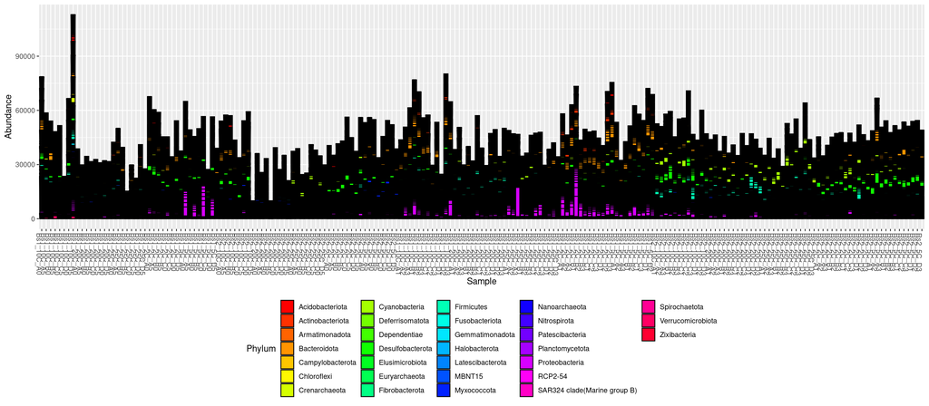

```r
plot_bar(ps, fill = "Phylum") + theme(legend.position="bottom" ) +  scale_fill_manual(values = rainbow(length(unique(tax_table(ps)[,"Phylum"]))))
```

# Cleanup

Save object

```r
dir.create("rdata_objects", showWarnings = FALSE)
save(ps, file=file.path("rdata_objects", "initial_rooted.Rdata"))
```

```r
download.file("https://raw.githubusercontent.com/ucdavis-bioinformatics-training/2021-May-Microbial-Community-Analysis/master/data_analysis/mca_part2.Rmd", "/mnt/c/Users/noahs/Desktop/2021-mca_workshop/03-DADA2/mca_part2.Rmd")
```